# Repurp: Drug–Gene Interaction Network Visualisation

Repurp

Drug–Gene Interaction Network Visualisation · v0.2.0

[figure not shown]

# Repurp: Drug–Gene Interaction Network Visualisation

A Complete Workflow for Drug Repurposing Studies

Lucas VH Tran

2026-06-09

# Introduction

**Visualisation backends:**

| # | Function(s) | Engine | Output | Best for |
| --- | --- | --- | --- | --- |
| 1 | `plot_dgi_igraph()` / `plot_dgi_igraph_core()` | igraph + qgraph | SVG + PNG | Fast bipartite, large networks |
| 2 | `plot_dgi_tripartite_igraph()` | igraph + qgraph | SVG + PNG | Gene × Drug × Pathway (base R) |
| 3 | `plot_dgi_ggraph()` / `plot_dgi_ggraph_core()` | ggraph + tidygraph | SVG + PNG | Tripartite, publication panels |
| 4 | `plot_dgi_ggraph_enhanced()` | ggraph + ggrepel + ggnewscale | SVG + PNG | Hub-labelled FR-layout, journals |
| 5 | `plot_dgi_ad_network()` | ggplot2 + ggrepel | SVG + PNG | Curated AD drug–biomarker network |
| 6 | `build_visnetwork()` / `build_visnetwork_tripartite()` | visNetwork | Interactive HTML | Exploratory, supplementary data |
| 7 | `plot_chord_dgi()` / `plot_chord_dgi_combined()` | circlize | SVG | Drug class overview, talks |
| 8 | `plot_dgi_heatmap()` | ggplot2 | SVG + PNG | Drug × Gene tile matrix |
| 9 | `plot_dgi_sankey()` | ggplot2 + ggalluvial | SVG + PNG | Drug class → Drug → Gene flow |
| 10 | `plot_dgi_dotmatrix()` | ggplot2 | SVG + PNG | Gene × Drug-class bubble matrix |

# Installation

```r
# Install from local source build
install.packages("path/to/Repurp", repos = NULL, type = "source")

# Core suggested packages (all visualisations)
install.packages(c(
  "ggplot2", "ggrepel", "ggnewscale",   # ggraph-family plots
  "ggraph", "tidygraph",                 # ggraph layouts
  "visNetwork",                          # interactive HTML
  "circlize",                            # chord diagrams
  "ggalluvial"                           # Sankey flow diagram
))
```

# Package data

```r
library(Repurp)
library(dplyr)
```

## Curated AD drugs

`repurp_ad_drugs()` returns a tibble of 18 established AD treatments with drug class and molecular targets:

```r
repurp_ad_drugs()
```

```
#> # A tibble: 18 × 4
#>    drug_name      brand      category              targets_known
#>    <chr>          <chr>      <chr>                 <chr>
#>  1 Hydrocortisone ""         Corticosteroid        NR3C1 (GR)
#>  2 Triamcinolone  ""         Corticosteroid        NR3C1 (GR)
#>  3 Betamethasone  ""         Corticosteroid        NR3C1 (GR)
#>  4 Tacrolimus     "Protopic" Calcineurin inhibitor FKBP1A; PPP3CA
#>  5 Pimecrolimus   "Elidel"   Calcineurin inhibitor FKBP1A; PPP3CA
#>  6 Cyclosporine   ""         Calcineurin inhibitor PPP3CA; PPP3CB
#>  7 Crisaborole    "Eucrisa"  PDE4 inhibitor        PDE4B; PDE4D
#>  8 Roflumilast    "Zoryve"   PDE4 inhibitor        PDE4A; PDE4B; PDE4D
#>  9 Ruxolitinib    "Opzelura" JAK inhibitor         JAK1; JAK2
#> 10 Upadacitinib   "Rinvoq"   JAK inhibitor         JAK1
#> 11 Abrocitinib    "Cibinqo"  JAK inhibitor         JAK1
#> 12 Baricitinib    "Olumiant" JAK inhibitor         JAK1; JAK2
#> 13 Dupilumab      "Dupixent" Biologic              IL4R
#> 14 Tralokinumab   "Adbry"    Biologic              IL13
#> 15 Lebrikizumab   "Ebglyss"  Biologic              IL13
#> 16 Nemolizumab    "Nemluvio" Biologic              IL31RA
#> 17 Tapinarof      "Vtama"    AhR agonist           AHR
#> 18 Methotrexate   ""         Immunosuppressant     DHFR; ATIC
```

## Curated MOA edges

`repurp_ad_edges()` returns 106 mechanism-of-action (MOA) edges linking each AD drug to biomarker genes with edge type (`"direct"` or `"indirect"`):

```r
repurp_ad_edges() |> dplyr::count(from, edge_type) |> head(12)
```

```
#> # A tibble: 12 × 3
#>    from           edge_type     n
#>    <chr>          <chr>     <int>
#>  1 Abrocitinib    indirect      7
#>  2 Baricitinib    indirect      7
#>  3 Betamethasone  indirect      8
#>  4 Crisaborole    indirect      5
#>  5 Cyclosporine   indirect      7
#>  6 Dupilumab      direct        1
#>  7 Hydrocortisone indirect     11
#>  8 Lebrikizumab   direct        1
#>  9 Methotrexate   indirect     10
#> 10 Nemolizumab    indirect      3
#> 11 Pimecrolimus   indirect      5
#> 12 Roflumilast    indirect      7
```

## Colour palettes

```r
# Edge / interaction-type palette (14 types)
data.frame(type = names(dgi_edge_colors), hex = dgi_edge_colors)
```

```
#>                            type     hex
#> INHIBITOR             INHIBITOR #E41A1C
#> AGONIST                 AGONIST #377EB8
#> ANTAGONIST           ANTAGONIST #FF7F00
#> ACTIVATOR             ACTIVATOR #4DAF4A
#> BINDER                   BINDER #984EA3
#> BLOCKER                 BLOCKER #A65628
#> MODULATOR             MODULATOR #F781BF
#> SUBSTRATE             SUBSTRATE #66C2A5
#> Inverse Agonist Inverse Agonist #FB8072
#> Antibody               Antibody #8DD3C7
#> Cleavage               Cleavage #BEBADA
#> Other                     Other #BDBDBD
#> None                       None #999999
#> Curated MOA         Curated MOA #404040
```

```r
# Node-type palette
dgi_node_colors
```

```
#>      Gene      Drug   Pathway
#> "#009E73" "#F0E442" "#6A3D9A"
```

```r
# Drug-class palette (13 classes)
data.frame(class = names(repurp_class_colors()), hex = repurp_class_colors())
```

```
#>                                       class     hex
#> Corticosteroid               Corticosteroid #E41A1C
#> Calcineurin inhibitor Calcineurin inhibitor #FF7F00
#> PDE4 inhibitor               PDE4 inhibitor #377EB8
#> JAK inhibitor                 JAK inhibitor #4DAF4A
#> Biologic                           Biologic #984EA3
#> AhR agonist                     AhR agonist #F781BF
#> Immunosuppressant         Immunosuppressant #A65628
#> Inhibitor                         Inhibitor #FB9A99
#> Agonist                             Agonist #A6CEE3
#> Antagonist                       Antagonist #FDBF6F
#> Binder                               Binder #CAB2D6
#> Activator                         Activator #B2DF8A
#> Other                                 Other #BDBDBD
```

# Synthetic demo dataset

All examples below use a small in-memory dataset built from the curated AD data, so you can run the vignette without a DGIdb download.

```r
# Compact synthetic DGI table (30 gene–drug edges)
synth_dgi <- tibble::tribble(
  ~Gene,     ~Drug,             ~InteractionType,
  "IL13",    "Dupilumab",       "INHIBITOR",
  "IL4R",    "Dupilumab",       "INHIBITOR",
  "IL13",    "Tralokinumab",    "INHIBITOR",
  "IL13",    "Lebrikizumab",    "INHIBITOR",
  "JAK1",    "Upadacitinib",    "INHIBITOR",
  "JAK1",    "Abrocitinib",     "INHIBITOR",
  "JAK1",    "Baricitinib",     "INHIBITOR",
  "JAK2",    "Baricitinib",     "INHIBITOR",
  "JAK2",    "Ruxolitinib",     "INHIBITOR",
  "JAK1",    "Ruxolitinib",     "INHIBITOR",
  "PDE4B",   "Crisaborole",     "INHIBITOR",
  "PDE4D",   "Crisaborole",     "INHIBITOR",
  "PDE4A",   "Roflumilast",     "INHIBITOR",
  "PDE4B",   "Roflumilast",     "INHIBITOR",
  "IL31RA",  "Nemolizumab",     "INHIBITOR",
  "AHR",     "Tapinarof",       "AGONIST",
  "NR3C1",   "Hydrocortisone",  "AGONIST",
  "NR3C1",   "Triamcinolone",   "AGONIST",
  "NR3C1",   "Betamethasone",   "AGONIST",
  "FKBP1A",  "Tacrolimus",      "BINDER",
  "FKBP1A",  "Pimecrolimus",    "BINDER",
  "PPP3CA",  "Tacrolimus",      "INHIBITOR",
  "PPP3CA",  "Cyclosporine",    "INHIBITOR",
  "DHFR",    "Methotrexate",    "INHIBITOR",
  "ATIC",    "Methotrexate",    "INHIBITOR",
  "IL18",    "Hydrocortisone",  "MODULATOR",
  "IL22",    "Triamcinolone",   "MODULATOR",
  "IL33",    "Betamethasone",   "MODULATOR",
  "STAT6",   "Upadacitinib",    "INHIBITOR",
  "TSLP",    "Dupilumab",       "MODULATOR"
)

# Verify the standardised structure
glimpse(synth_dgi)
```

```
#> Rows: 30
#> Columns: 3
#> $ Gene            <chr> "IL13", "IL4R", "IL13", "IL13", "JAK1", "JAK1", "JAK1"…
#> $ Drug            <chr> "Dupilumab", "Dupilumab", "Tralokinumab", "Lebrikizuma…
#> $ InteractionType <chr> "INHIBITOR", "INHIBITOR", "INHIBITOR", "INHIBITOR", "I…
```

## Preparing DGIdb data (your own files)

If you have downloaded interaction data from [DGIdb v5](https://www.dgidb.org/), use `prepare_dgi_data()` to standardise it:

```r
net_dat <- prepare_dgi_data(
  interactions = "interactions.tsv",   # path to DGIdb TSV download
  gene_list    = c("IL13", "IL4R", "JAK1", "JAK2", "PDE4B", "TSLP")
)
```

`prepare_dgi_data()` normalises column names, coerces `NA`/empty interaction types to `"None"`, and filters to your gene list.

# Part 1: Candidate prioritisation and coverage analysis

The analysis helpers convert visual network edges into ranked repurposing tables. They accept the package’s common edge formats, including `Gene` / `Drug` / `InteractionType`, DGIdb-style columns, and `from` / `to` edge lists.

```r
dgi_std <- standardize_dgi_edges(synth_dgi)
dgi_std |> head(8)
```

```
#> # A tibble: 8 × 3
#>   gene  drug         interaction_type
#>   <chr> <chr>        <chr>
#> 1 IL13  Dupilumab    INHIBITOR
#> 2 IL4R  Dupilumab    INHIBITOR
#> 3 IL13  Tralokinumab INHIBITOR
#> 4 IL13  Lebrikizumab INHIBITOR
#> 5 JAK1  Upadacitinib INHIBITOR
#> 6 JAK1  Abrocitinib  INHIBITOR
#> 7 JAK1  Baricitinib  INHIBITOR
#> 8 JAK2  Baricitinib  INHIBITOR
```

## 1a - Rank candidate drugs

`score_drug_repurposing()` ranks drugs by weighted biomarker coverage. Use `gene_weights` to prioritise biomarkers from differential-expression, proteomics, GWAS, or pathway analyses.

```r
biomarkers <- c("IL13", "IL4R", "JAK1", "JAK2", "PDE4B", "TSLP")

ranked_drugs <- score_drug_repurposing(
  dgi_std,
  biomarkers = biomarkers,
  gene_weights = c(IL13 = 2, IL4R = 2, JAK1 = 1.5, JAK2 = 1, PDE4B = 1, TSLP = 1.5)
)

ranked_drugs |>
  dplyr::select(rank, drug, category, score, target_count, coverage, targets)
```

```
#> # A tibble: 9 × 7
#>    rank drug         category       score target_count coverage targets
#>   <int> <chr>        <chr>          <dbl>        <int>    <dbl> <chr>
#> 1     1 Dupilumab    Biologic         5.5            3    0.5   IL13; IL4R; TSLP
#> 2     2 Baricitinib  JAK inhibitor    2.5            2    0.333 JAK1; JAK2
#> 3     3 Ruxolitinib  JAK inhibitor    2.5            2    0.333 JAK1; JAK2
#> 4     4 Lebrikizumab Biologic         2              1    0.167 IL13
#> 5     5 Tralokinumab Biologic         2              1    0.167 IL13
#> 6     6 Abrocitinib  JAK inhibitor    1.5            1    0.167 JAK1
#> 7     7 Upadacitinib JAK inhibitor    1.5            1    0.167 JAK1
#> 8     8 Crisaborole  PDE4 inhibitor   1              1    0.167 PDE4B
#> 9     9 Roflumilast  PDE4 inhibitor   1              1    0.167 PDE4B
```

## 1b - Biomarker and class coverage

Use `summarize_biomarker_coverage()` to find well-covered biomarkers and targets that may need additional evidence sources. Use `summarize_drug_classes()` to summarise the therapeutic classes represented in a network.

```r
summarize_biomarker_coverage(dgi_std, biomarkers = biomarkers) |>
  dplyr::select(gene, drug_count, drug_class_count, drugs)
```

```
#> # A tibble: 6 × 4
#>   gene  drug_count drug_class_count drugs
#>   <chr>      <int>            <int> <chr>
#> 1 JAK1           4                1 Abrocitinib; Baricitinib; Ruxolitinib; Upad…
#> 2 IL13           3                1 Dupilumab; Lebrikizumab; Tralokinumab
#> 3 JAK2           2                1 Baricitinib; Ruxolitinib
#> 4 PDE4B          2                1 Crisaborole; Roflumilast
#> 5 IL4R           1                1 Dupilumab
#> 6 TSLP           1                1 Dupilumab
```

```r
summarize_drug_classes(dgi_std, biomarkers = biomarkers) |>
  dplyr::select(category, drug_count, target_count, coverage, drugs)
```

```
#> # A tibble: 3 × 5
#>   category       drug_count target_count coverage drugs
#>   <chr>               <int>        <int>    <dbl> <chr>
#> 1 Biologic                3            3    0.5   Dupilumab; Lebrikizumab; Tral…
#> 2 JAK inhibitor           4            2    0.333 Abrocitinib; Baricitinib; Rux…
#> 3 PDE4 inhibitor          2            1    0.167 Crisaborole; Roflumilast
```

## 1c - Expression reversal scoring

`score_expression_reversal()` combines DGI edges with differential-expression statistics. Positive scores indicate interactions expected to oppose the disease expression direction, for example inhibition of an up-regulated biomarker.

```r
deg_stats <- tibble::tibble(
  gene = c("IL13", "IL4R", "JAK1", "JAK2", "PDE4B", "TSLP"),
  logFC = c(1.4, 1.1, 0.7, 0.5, 0.9, 1.2),
  padj = c(0.001, 0.002, 0.02, 0.04, 0.01, 0.005)
)

score_expression_reversal(dgi_std, deg_stats) |>
  dplyr::select(rank, drug, category, reversal_score, supportive_edges,
                conflicting_edges, targets)
```

```
#> # A tibble: 9 × 7
#>    rank drug  category reversal_score supportive_edges conflicting_edges targets
#>   <int> <chr> <chr>             <dbl>            <int>             <int> <chr>
#> 1     1 Dupi… Biologic           7.17                2                 0 IL13; …
#> 2     2 Lebr… Biologic           4.2                 1                 0 IL13
#> 3     3 Tral… Biologic           4.2                 1                 0 IL13
#> 4     4 Bari… JAK inh…           1.89                2                 0 JAK1; …
#> 5     5 Ruxo… JAK inh…           1.89                2                 0 JAK1; …
#> 6     6 Cris… PDE4 in…           1.8                 1                 0 PDE4B
#> 7     7 Rofl… PDE4 in…           1.8                 1                 0 PDE4B
#> 8     8 Abro… JAK inh…           1.19                1                 0 JAK1
#> 9     9 Upad… JAK inh…           1.19                1                 0 JAK1
```

For curated AD mechanism-of-action edges, direction is detected automatically:

```r
score_drug_repurposing(
  repurp_ad_edges(),
  biomarkers = biomarkers
) |>
  dplyr::select(rank, drug, category, score, target_count, coverage, targets) |>
  head(10)
```

```
#> # A tibble: 10 × 7
#>     rank drug           category             score target_count coverage targets
#>    <int> <chr>          <chr>                <dbl>        <int>    <dbl> <chr>
#>  1     1 Abrocitinib    JAK inhibitor            2            2    0.333 IL13; …
#>  2     2 Baricitinib    JAK inhibitor            2            2    0.333 IL13; …
#>  3     3 Betamethasone  Corticosteroid           2            2    0.333 IL13; …
#>  4     4 Crisaborole    PDE4 inhibitor           2            2    0.333 IL13; …
#>  5     5 Cyclosporine   Calcineurin inhibit…     2            2    0.333 IL13; …
#>  6     6 Hydrocortisone Corticosteroid           2            2    0.333 IL13; …
#>  7     7 Methotrexate   Immunosuppressant        2            2    0.333 IL13; …
#>  8     8 Nemolizumab    Biologic                 2            2    0.333 IL13; …
#>  9     9 Pimecrolimus   Calcineurin inhibit…     2            2    0.333 IL13; …
#> 10    10 Roflumilast    PDE4 inhibitor           2            2    0.333 IL13; …
```

# Part 2: igraph / qgraph static networks

The igraph backend draws using base-R `plot.igraph()` with a Fruchterman-Reingold layout computed by `qgraph`. Output is written to SVG + PNG when `out_dir` is specified.

## Layout algorithm

where $k = \sqrt{A / n}$ is the optimal pairwise distance ($A$ = canvas area, $n$ = node count). Nodes repel uniformly but only connected pairs attract.

## 1a — Full bipartite network

[figure not shown]

```r
plot_dgi_igraph(
  net_dat     = synth_dgi,
  title       = "AD Drug–Biomarker Network",
  gene_color  = "#009E73",
  drug_color  = "#F0E442",
  vertex_size = 7,
  label_cex   = 0.75
  # out_dir = "results/"  # uncomment to save SVG + PNG
)
```

Key parameters:

| Parameter | Default | Effect |
| --- | --- | --- |
| `vertex_size` | `6` | Node circle radius |
| `label_cex` | `0.7` | Label scaling factor |
| `area_factor` | `2.0` | Canvas area multiplier — increase to spread nodes |
| `repulse_factor` | `1.0` | Node repulsion strength |
| `gene_color` | `"#009E73"` | Gene node fill |
| `drug_color` | `"#F0E442"` | Drug node fill |

## 1b — Core network (hub genes only)

`plot_dgi_igraph_core()` filters to genes with ≥ `min_gene_edges` drug connections before plotting:

[figure not shown]

```r
plot_dgi_igraph_core(
  net_dat        = synth_dgi,
  title          = "Core AD Network — genes ≥ 2 drugs",
  min_gene_edges = 2L
)
```

## 1c — Tripartite: Gene × Drug × Pathway

`plot_dgi_tripartite_igraph()` accepts a third node type — **Pathway** — via `pathway_edges`. Without pathway edges it reduces to the bipartite case.

```r
# Build pathway_edges from STRING enrichment (see rbioapi)
library(rbioapi)
enrich <- rbioapi::rba_string_enrichment(ids = unique(synth_dgi$Gene), species = 9606)
pathway_edges <- dplyr::bind_rows(
  enrich[["KEGG"]] |> dplyr::mutate(category = "KEGG"),
  enrich[["Process"]] |> dplyr::mutate(category = "GO_Process")
) |>
  dplyr::filter(fdr < 0.05) |>
  tidyr::unnest(inputGenes) |>
  dplyr::select(from = inputGenes, to = description, edge_type = category)

dgi_e <- dplyr::select(synth_dgi, from = Gene, to = Drug, edge_type = InteractionType)

plot_dgi_tripartite_igraph(
  dgi_edges     = dgi_e,
  pathway_edges = pathway_edges,
  title         = "Tripartite: Gene × Drug × Pathway",
  out_dir       = "results/"
)
```

# Part 3: ggraph publication-quality networks

The ggraph backend returns a `ggplot` object — fully composable with `patchwork`, `cowplot`, and standard ggplot2 theming.

```r
# Convert to the from/to/edge_type format expected by all ggraph functions
dgi_e <- dplyr::transmute(
  synth_dgi,
  from      = Gene,
  to        = Drug,
  edge_type = InteractionType
)
```

## 2a — Full tripartite view

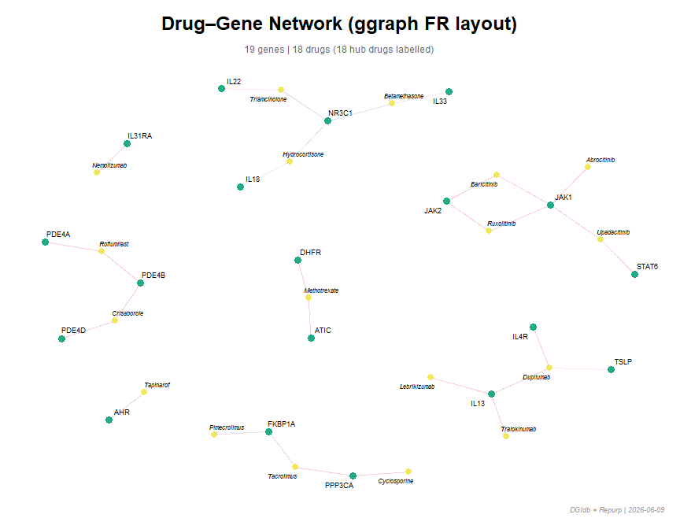

```r
p_full <- plot_dgi_ggraph(
  dgi_edges        = dgi_e,
  title            = "Drug–Gene Network (ggraph FR layout)",
  min_drug_targets = 1L,
  seed             = 42L
)
```

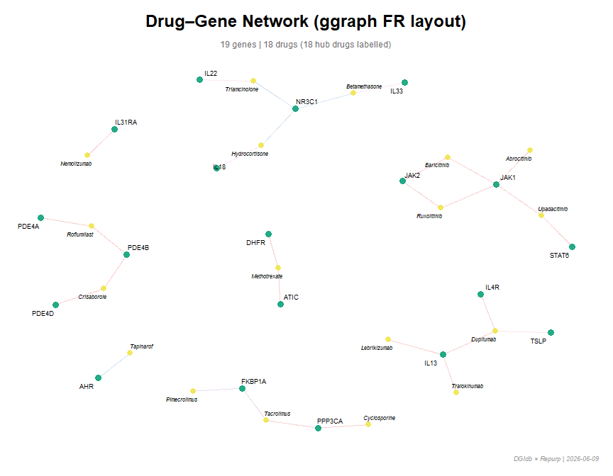

```r
p_full
```

## 2b — Core view (Kamada-Kawai layout)

`plot_dgi_ggraph_core()` uses a Kamada-Kawai layout (default) and labels every retained node:

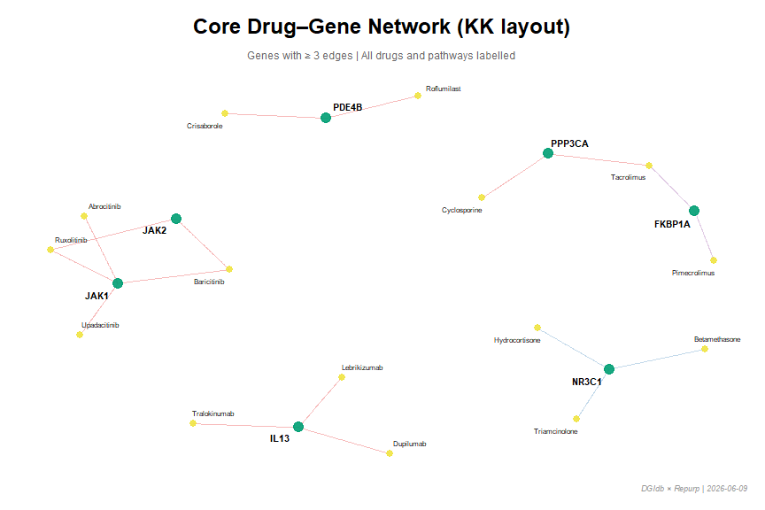

```r
p_core <- plot_dgi_ggraph_core(
  dgi_edges      = dgi_e,
  title          = "Core Drug–Gene Network (KK layout)",
  min_gene_edges = 2L,
  seed           = 42L
)
```

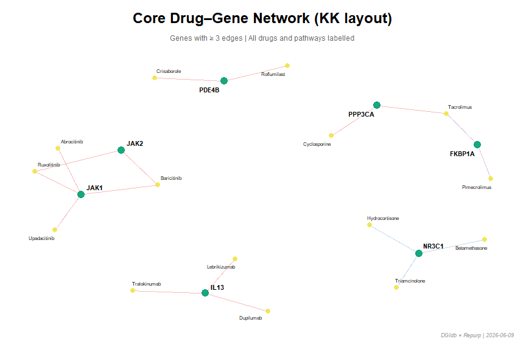

```r
p_core
```

## 2c — Enhanced: FR layout + ggrepel + ggnewscale

`plot_dgi_ggraph_enhanced()` uses a `qgraph` FR layout with separate colour scales for nodes and edges (via `ggnewscale`), and `ggrepel` for non-overlapping labels. Two modes are available:

### Full mode

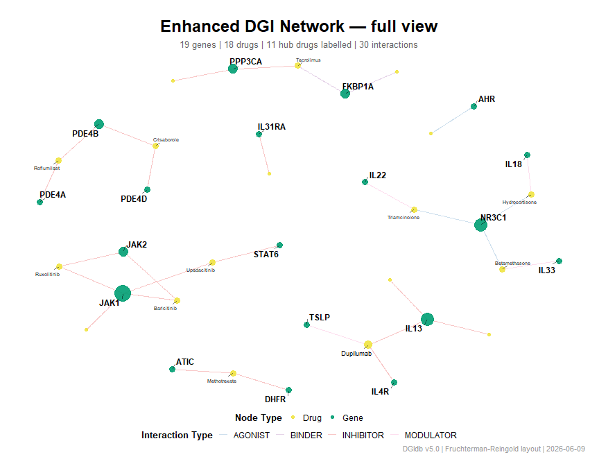

```r
p_enh_full <- plot_dgi_ggraph_enhanced(
  dgi_edges        = dgi_e,
  mode             = "full",
  title            = "Enhanced DGI Network — full view",
  min_drug_targets = 2L,
  seed             = 42L
)
```

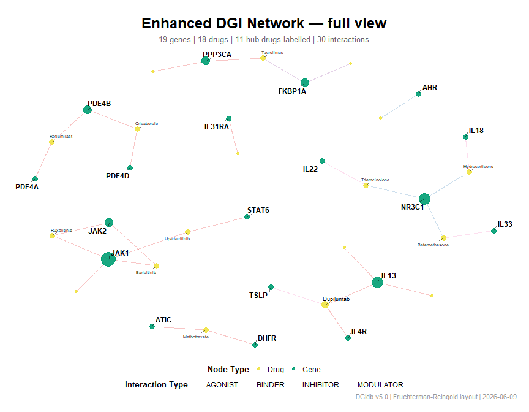

```r
p_enh_full
```

### Core mode

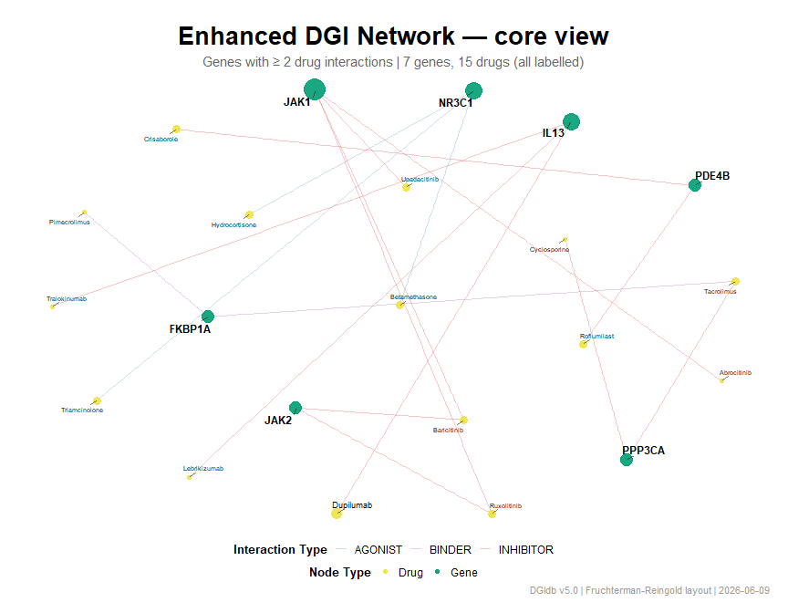

```r
p_enh_core <- plot_dgi_ggraph_enhanced(
  dgi_edges      = dgi_e,
  mode           = "core",
  title          = "Enhanced DGI Network — core view",
  min_gene_edges = 2L,
  seed           = 42L
)
```

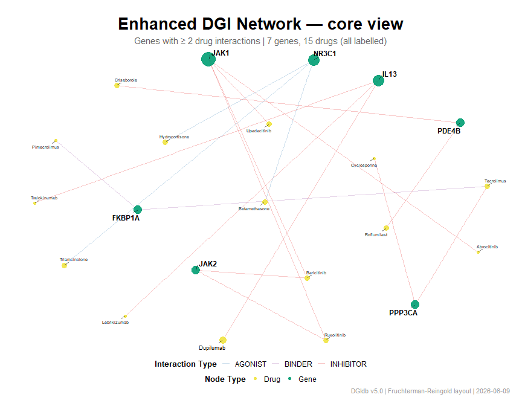

```r
p_enh_core
```

### Mode comparison

| Parameter | `"full"` | `"core"` |
| --- | --- | --- |
| Gene filter | none | genes ≥ `min_gene_edges` drugs |
| Drug labels | hub drugs only (≥ `min_drug_targets`) | all drugs |
| Layout area | `2 × n²·⁰⁵` | same |
| `ggrepel` force | `0.5` | `1.0` |
| Use case | complete landscape | focused hub view |

## 2d — AD drug–biomarker network

`plot_dgi_ad_network()` draws the curated AD drugs with drug-class colour coding and MOA edges:

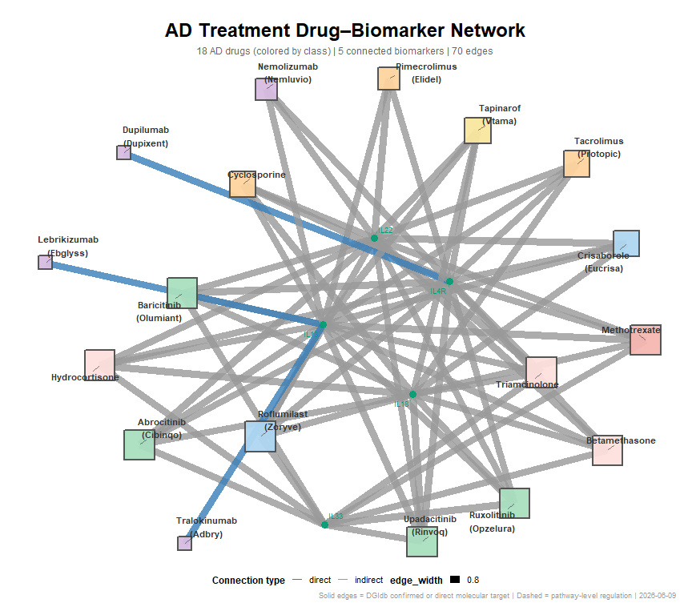

```r
# Filter curated edges to genes present in our demo dataset
ad_e <- repurp_ad_edges() |>
  dplyr::filter(to %in% unique(synth_dgi$Gene))

p_adn <- plot_dgi_ad_network(
  edges     = ad_e,
  drug_info = repurp_ad_drugs(),
  title     = "AD Treatment Drug–Biomarker Network"
)
```

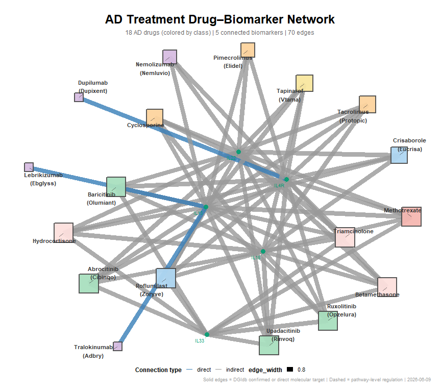

```r
p_adn
```

Drug nodes are coloured by therapeutic category. Solid edges = direct molecular target or DGIdb confirmed; dashed edges = pathway-level regulation.